# Project Python Foundations: FoodHub Data Analysis

### Context

The number of restaurants in New York is increasing day by day. Lots of students and busy professionals rely on those restaurants due to their hectic lifestyles. Online food delivery service is a great option for them. It provides them with good food from their favorite restaurants. A food aggregator company FoodHub offers access to multiple restaurants through a single smartphone app.

The app allows the restaurants to receive a direct online order from a customer. The app assigns a delivery person from the company to pick up the order after it is confirmed by the restaurant. The delivery person then uses the map to reach the restaurant and waits for the food package. Once the food package is handed over to the delivery person, he/she confirms the pick-up in the app and travels to the customer's location to deliver the food. The delivery person confirms the drop-off in the app after delivering the food package to the customer. The customer can rate the order in the app. The food aggregator earns money by collecting a fixed margin of the delivery order from the restaurants.

### Objective

The food aggregator company has stored the data of the different orders made by the registered customers in their online portal. They want to analyze the data to get a fair idea about the demand of different restaurants which will help them in enhancing their customer experience. Suppose you are hired as a Data Scientist in this company and the Data Science team has shared some of the key questions that need to be answered. Perform the data analysis to find answers to these questions that will help the company to improve the business.

### Data Description

The data contains the different data related to a food order. The detailed data dictionary is given below.

### Data Dictionary

- order_id: Unique ID of the order
- customer_id: ID of the customer who ordered the food
- restaurant_name: Name of the restaurant
- cuisine_type: Cuisine ordered by the customer
- cost_of_the_order: Cost of the order
- day_of_the_week: Indicates whether the order is placed on a weekday or weekend (The weekday is from Monday to Friday and the weekend is Saturday and Sunday)
- rating: Rating given by the customer out of 5
- food_preparation_time: Time (in minutes) taken by the restaurant to prepare the food. This is calculated by taking the difference between the timestamps of the restaurant's order confirmation and the delivery person's pick-up confirmation.
- delivery_time: Time (in minutes) taken by the delivery person to deliver the food package. This is calculated by taking the difference between the timestamps of the delivery person's pick-up confirmation and drop-off information

### Let us start by importing the required libraries

```python
# Installing the libraries with the specified version.
!pip install numpy==1.25.2 pandas==1.5.3 matplotlib==3.7.1 seaborn==0.13.1 -q --user
```

[output not shown]

**Note**:

- After running the above cell, kindly restart the runtime (for Google Colab) or notebook kernel (for Jupyter Notebook), and run all cells sequentially from the next cell.
- On executing the above line of code, you might see a warning regarding package dependencies. This error message can be ignored as the above code ensures that all necessary libraries and their dependencies are maintained to successfully execute the code in **this notebook**.

```python
# import libraries for data manipulation
import numpy as np
import pandas as pd

# import libraries for data visualization
import matplotlib.pyplot as plt
import seaborn as sns
```

### Understanding the structure of the data

```python
# uncomment and run the below code snippets if the dataset is present in the Google Drive
from google.colab import drive
drive.mount('/content/drive')
```

```python
# Reads CSV file
df = pd.read_csv('/content/drive/MyDrive/PGAT-2025/PythonFoundations/FoodHubProject/foodhub_order.csv')
```

```python
# First five rows of the dataset
df.head()
```

|  | order_id | customer_id | restaurant_name | cuisine_type | cost_of_the_order | day_of_the_week | rating | food_preparation_time | delivery_time |
| --- | --- | --- | --- | --- | --- | --- | --- | --- | --- |
| 0 | 1477147 | 337525 | Hangawi | Korean | 30.75 | Weekend | Not given | 25 | 20 |
| 1 | 1477685 | 358141 | Blue Ribbon Sushi Izakaya | Japanese | 12.08 | Weekend | Not given | 25 | 23 |
| 2 | 1477070 | 66393 | Cafe Habana | Mexican | 12.23 | Weekday | 5 | 23 | 28 |
| 3 | 1477334 | 106968 | Blue Ribbon Fried Chicken | American | 29.20 | Weekend | 3 | 25 | 15 |
| 4 | 1478249 | 76942 | Dirty Bird to Go | American | 11.59 | Weekday | 4 | 25 | 24 |

### **Question 1:** How many rows and columns are present in the data? [0.5 mark]

```python
# Shows the shape of the dataset
print('There are ' + str(df.shape[0]) + ' rows and ' + str(df.shape[1]) + ' columns present in the dataset.')
```

```
There are 1898 rows and 9 columns present in the dataset.
```

#### Observations: There are 1898 rows and 9 columns present in the dataset.

### **Question 2:** What are the datatypes of the different columns in the dataset? (The info() function can be used) [0.5 mark]

```python
# Datatypes in the dataset
df.info()
```

```
<class 'pandas.core.frame.DataFrame'>
RangeIndex: 1898 entries, 0 to 1897
Data columns (total 9 columns):
 #   Column                 Non-Null Count  Dtype
---  ------                 --------------  -----
 0   order_id               1898 non-null   int64
 1   customer_id            1898 non-null   int64
 2   restaurant_name        1898 non-null   object
 3   cuisine_type           1898 non-null   object
 4   cost_of_the_order      1898 non-null   float64
 5   day_of_the_week        1898 non-null   object
 6   rating                 1898 non-null   object
 7   food_preparation_time  1898 non-null   int64
 8   delivery_time          1898 non-null   int64
dtypes: float64(1), int64(4), object(4)
memory usage: 133.6+ KB
```

```python
# Transforms order_id and customer_id in strings
df['order_id'] = df['order_id'].astype('str')
df['customer_id'] = df['customer_id'].astype('str')
```

```python
df.info()
```

```
<class 'pandas.core.frame.DataFrame'>
RangeIndex: 1898 entries, 0 to 1897
Data columns (total 9 columns):
 #   Column                 Non-Null Count  Dtype
---  ------                 --------------  -----
 0   order_id               1898 non-null   object
 1   customer_id            1898 non-null   object
 2   restaurant_name        1898 non-null   object
 3   cuisine_type           1898 non-null   object
 4   cost_of_the_order      1898 non-null   float64
 5   day_of_the_week        1898 non-null   object
 6   rating                 1898 non-null   object
 7   food_preparation_time  1898 non-null   int64
 8   delivery_time          1898 non-null   int64
dtypes: float64(1), int64(2), object(6)
memory usage: 133.6+ KB
```

#### Observations:

There are three different data types present in the dataset:

```
object (string): restaurante_name, cuisine_type, day_of_the_week and rating
int: order_id, customer_id, food_preparation_time and delivery_time
float: cost_of_the_order
```

Order_id and customer_id are unique keys, so both columns were transformed in string to facilitate the analysis.

### **Question 3:** Are there any missing values in the data? If yes, treat them using an appropriate method. [1 mark]

#### Checking for any missing values in the dataset

```python
# Checks for any missing values

df.info()
```

```
<class 'pandas.core.frame.DataFrame'>
RangeIndex: 1898 entries, 0 to 1897
Data columns (total 9 columns):
 #   Column                 Non-Null Count  Dtype
---  ------                 --------------  -----
 0   order_id               1898 non-null   object
 1   customer_id            1898 non-null   object
 2   restaurant_name        1898 non-null   object
 3   cuisine_type           1898 non-null   object
 4   cost_of_the_order      1898 non-null   float64
 5   day_of_the_week        1898 non-null   object
 6   rating                 1898 non-null   object
 7   food_preparation_time  1898 non-null   int64
 8   delivery_time          1898 non-null   int64
dtypes: float64(1), int64(2), object(6)
memory usage: 133.6+ KB
```

```python
# Checks for any missing values
df.isnull().sum()
```

|  | 0 |
| --- | --- |
| order_id | 0 |
| customer_id | 0 |
| restaurant_name | 0 |
| cuisine_type | 0 |
| cost_of_the_order | 0 |
| day_of_the_week | 0 |
| rating | 0 |
| food_preparation_time | 0 |
| delivery_time | 0 |

**dtype:** int64

#### Checking categorical string values in the dataset

```python
df['rating'].value_counts(normalize=True)
```

| rating | proportion |
| --- | --- |
| Not given | 0.387777 |
| 5 | 0.309800 |
| 4 | 0.203372 |
| 3 | 0.099052 |

**dtype:** float64

```python
df['day_of_the_week'].value_counts(normalize=True)
```

| day_of_the_week | proportion |
| --- | --- |
| Weekend | 0.711802 |
| Weekday | 0.288198 |

**dtype:** float64

```python
df['cuisine_type'].value_counts(normalize=True)
```

| cuisine_type | proportion |
| --- | --- |
| American | 0.307692 |
| Japanese | 0.247629 |
| Italian | 0.157007 |
| Chinese | 0.113277 |
| Mexican | 0.040569 |
| Indian | 0.038462 |
| Middle Eastern | 0.025817 |
| Mediterranean | 0.024236 |
| Thai | 0.010011 |
| French | 0.009484 |
| Southern | 0.008957 |
| Korean | 0.006849 |
| Spanish | 0.006322 |
| Vietnamese | 0.003688 |

**dtype:** float64

#### Treating "Not Given" values for column Rating

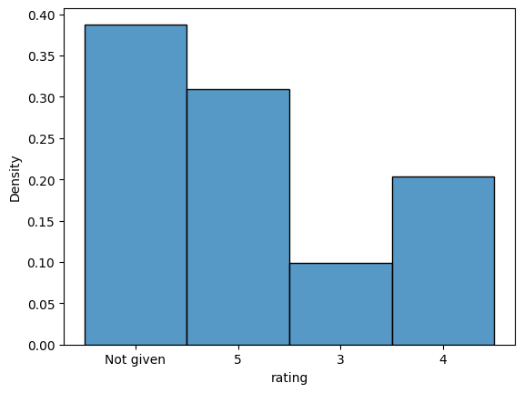

```python
# Plots the distribution for column "Rating"
sns.histplot(data=df,x='rating',stat='density')
plt.show()
```

```python
# Get a copy of the dataset to perform the changes and mantain the original dataset for future reference
df_treated = df.copy()
```

```python
# Transforms "Not given" values in NaN to use fillna function further on
df_treated['rating'] = df_treated['rating'].replace('Not given', np.nan)

# Uses fillna function to fill NaN values with the mode of the column, since it is a string
df_treated['rating'] = df_treated['rating'].fillna(df_treated.groupby('restaurant_name')['rating'].transform(lambda x: x.mode()[0] if not x.mode().empty else None))
```

```python
# Checks the performance of the code above
df_treated.isnull().sum()
```

|  | 0 |
| --- | --- |
| order_id | 0 |
| customer_id | 0 |
| restaurant_name | 0 |
| cuisine_type | 0 |
| cost_of_the_order | 0 |
| day_of_the_week | 0 |
| rating | 30 |
| food_preparation_time | 0 |
| delivery_time | 0 |

**dtype:** int64

```python
# Drops the remaining missing values
df_treated = df_treated.dropna(axis=0)
df_treated.info()
```

```
<class 'pandas.core.frame.DataFrame'>
Index: 1868 entries, 1 to 1897
Data columns (total 9 columns):
 #   Column                 Non-Null Count  Dtype
---  ------                 --------------  -----
 0   order_id               1868 non-null   object
 1   customer_id            1868 non-null   object
 2   restaurant_name        1868 non-null   object
 3   cuisine_type           1868 non-null   object
 4   cost_of_the_order      1868 non-null   float64
 5   day_of_the_week        1868 non-null   object
 6   rating                 1868 non-null   object
 7   food_preparation_time  1868 non-null   int64
 8   delivery_time          1868 non-null   int64
dtypes: float64(1), int64(2), object(6)
memory usage: 145.9+ KB
```

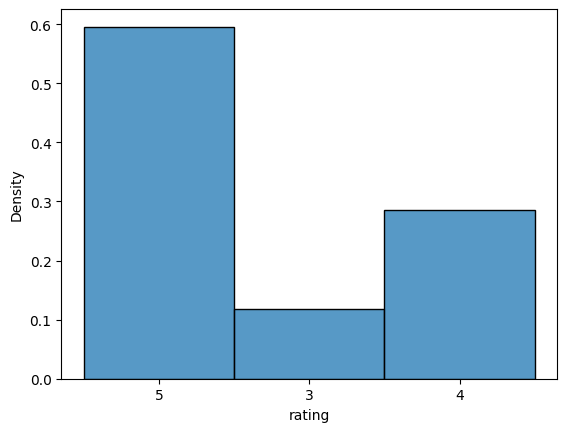

```python
# Plots column "Rating" new distribution
sns.histplot(data=df_treated,x='rating',stat='density')
plt.show()
```

#### Observations:

By using the info() function, it is possible to observe that there are no missing values in the dataset, and the isnull() function confirms it. However, the "rating" column contains "Not given" entries, which make up 38% of the data. These entries are not missing values per se, but they should be treated to improve the results of the analysis.

To improve the analysis, the "Not given" ratings were replaced with the most common (mode) rating for each restaurant. Thus, assuming that a restaurant would likely receive the most frequent rating from its historical data.

The modified dataset is saved as df_treated to preserve the original dataset for future reference.

### **Question 4:** Check the statistical summary of the data. What is the minimum, average, and maximum time it takes for food to be prepared once an order is placed? [2 marks]

```python
# Checks the statistical summary of the data

df_treated.describe().T
```

|  | count | mean | std | min | 25% | 50% | 75% | max |
| --- | --- | --- | --- | --- | --- | --- | --- | --- |
| cost_of_the_order | 1868.0 | 16.512195 | 7.473723 | 4.47 | 12.08 | 14.16 | 22.2725 | 35.41 |
| food_preparation_time | 1868.0 | 27.361349 | 4.628866 | 20.00 | 23.00 | 27.00 | 31.0000 | 35.00 |
| delivery_time | 1868.0 | 24.185225 | 4.960147 | 15.00 | 20.00 | 25.00 | 28.0000 | 33.00 |

#### Observations:

The statistical summay shows the distribution of food preparation times: the minimum is 20 minutes, the mean is 27 minutes and the maximum is 35 minutes.

### **Question 5:** How many orders are not rated? [1 mark]

```python
# Shows the different values in the "Rating" column
df['rating'].value_counts()
```

| rating | count |
| --- | --- |
| Not given | 736 |
| 5 | 588 |
| 4 | 386 |
| 3 | 188 |

**dtype:** int64

```python
df['rating'].value_counts(normalize=True)
```

| rating | proportion |
| --- | --- |
| Not given | 0.387777 |
| 5 | 0.309800 |
| 4 | 0.203372 |
| 3 | 0.099052 |

**dtype:** float64

#### Observations:

In the original dataset, 736 orders were not rated, which makes up to 38% of the entries. Those records have been treated in Question 3.